# CPLN 590 Final Project

Evan Cernea and Xiaoxia Dong

December 20, 2017

# Motivation and Use Case

In 2013, Divvy launched their bikeshare program in Chicago. They started with 1300 bikes in and around the Loop, Chicago’s central business district. They were instantly popular. But with the popularity came growing pains. In 2014, when Divvy was trying to expand, both their supplier and parent company faced bankruptcy. Users were complaining that there were not enough bikes, too few stops, and not enough spaces at those stops. Even though the bikeshare program was eventually able to expand, there are still issues making sure there are enough bikes to meet demands, especially in the Loop.

We want bikeshare programs to remain vibrant, but we’re already at capacity for the number of bikes in the system given space constraints. For Divvy to optimize operations and maximize efficiency, being able to predict bicycle usage particularly bike departure at each station at any given any hour becomes crucial. It will help direct rebalancers to stations with many bikes to move those bikes to stations with few bikes.

Our goal is to make it so that rebalancers are moving bikes from low-demand locations to high-demand locations. We want to make sure that there are never bike stations where there are too few bikes to meet demand, especially in the Loop.

Our analysis predicts demand, represented by number of checkouts, at bike stations given socio-demographic, time, and environmental variables. The analysis is necessary for alerting rebalancers to what stations are in the highest demand and will most likely need bikes in the near future.

# Scope of Analysis

Using ArcGIS, we selected the 150 closest Divvy stations to the center of the Loop. The map, Bike Stations Near the Loop, shows these stations within the context of Chicago’s CBD. We selected the month of March 2017 as the time frame for our analysis.

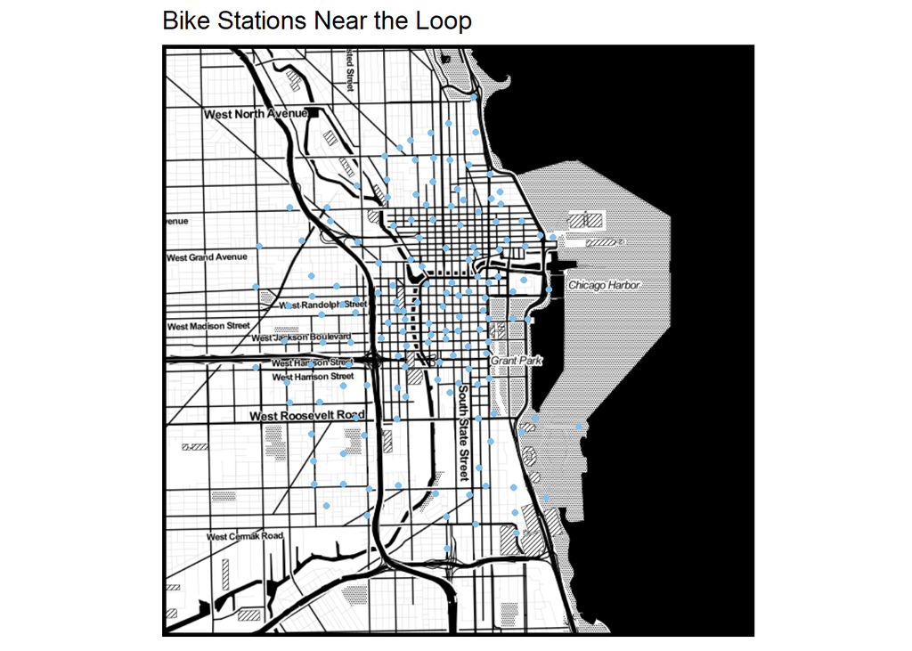

```r
ggmap(baseMap) +
  geom_point(data = bike_stations, colour = "#83BFE8",
             aes(x=longitude, y=latitude),
             size = 1.5) +
  labs(title="Bike Stations Near the Loop") +
  mapTheme()
```

# Data Cleaning and Variable Engineering

To facilitate our model building, we collected and created a series of temporal, socio-demographic, weather, and spatial variables.

Temporally, we created time lag variables. These variables associate the number of checkouts at each station at a given hour with the number of checkouts at a previous time point. For example, a 1-hour lag pairs the number of checkouts between 3 and 4 pm at station A with the number of checkouts between 2 and 3 pm at the same station. The temporal variables in this analysis include 1-hour, 2-hour, 1-day, 2-day, 3-day, 4-day, and 1-week. We did not include activities between midnight and 5 am in this analysis due to the low usage of bike share.

## Socio-demographic data

Socio-demographically, we collected population, employment, the number of white workers, the number of workers with college degree or higher, and the number of workers under 30 years of age as our predictors. We also collected the number of white residents, the number of residents with college degree or higher, and the number of residents under 30 years of age as our predictors. All these data are published by the US Census Bureau, and they are aggregated to the census block level. Additionally, we also calculated the density for each of these predictors. Several studies have shown that these variables are closely related to bike usage.

[interactive chart not shown]

Weather is another important factor affecting people’s biking behavior. We therefore also considered temperature and precipitation. We took daily weather data from the NOAA Observation site at Chicago-Midway Airport for the month of March.

We considered a series of spatial factors. Using “Generate Near Table”" in GIS, we calculated the distance from each bike station to the nearest attractions, using parks (centroid), public libraries, and the Loop as a proxy. We also calculated the distance between each bike station to its nearest bike station. To figure out the median distance to all 149 other bike stations, we used the ArcGIS feature “Generate Near Table” to find the distance from each station to all the other stations in the dataset. We then used dplyr functions in R to group by each station and find the median distance from each station to the other stations. We assumed that the distance to both local attractions and other bike stations would affect bike usage.

We calculated the density for each of the socio-demographic variables explained above.

Lastly, we created a few fixed effect variables. Firstly, we suspected that bike usage may vary dramatically between weekdays and weekends. To account for this factor, we created a fixed effect for weekend days.

Secondely, we realized that more heavily used stations may share certain common characteristics with one another. We therefore decided to single out the outlying stations to create a station fixed effect.

Unfortunately, there are many missing values in the resident census file. We therefore decided to delete the five residential variables from our dataset. However, we keep the code in the markdown file so that interested parties could replicate our work when data become available in the future.

## Variable Visualization

The first thing that stands out is the fact that the number of checkouts is not normally distributed as shown in the plot below. Instead, most stations saw very few checkout at any given hour. The long tail of the plot suggests that while the number of checkouts are concentrated on the left side of the plot, there are a few outliers with relatively higher level of bike usage.

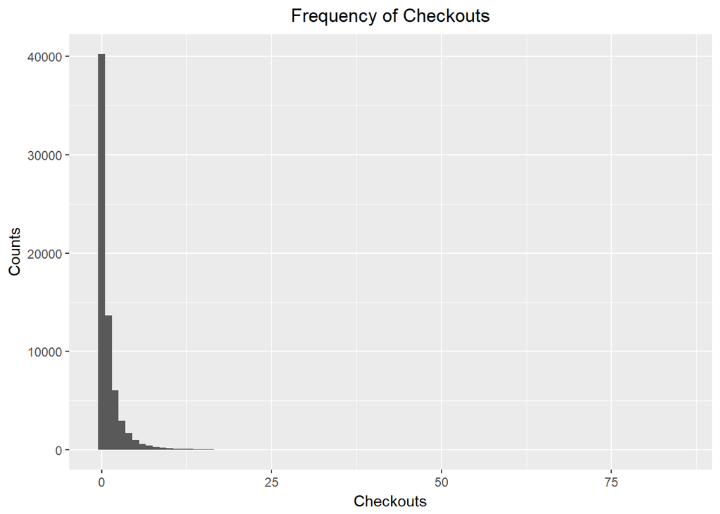

```r
knitr::opts_chunk$set(echo = TRUE, fig.width=8, fig.height=8)
ggplot(dat.full.short, aes(checkout)) +
  geom_histogram(binwidth = 1) +
  labs(title = "Frequency of Checkouts",
       x = "Checkouts",
       y = "Counts") +
  theme(plot.title = element_text(hjust = 0.5))
```

Upon examination, we found a positive relationship between the actual checkouts at any given hour, and their associated lags. The plots below show a few of these relationships. These correlations indicate that it is reasonable to use the lags as predictors in our models.

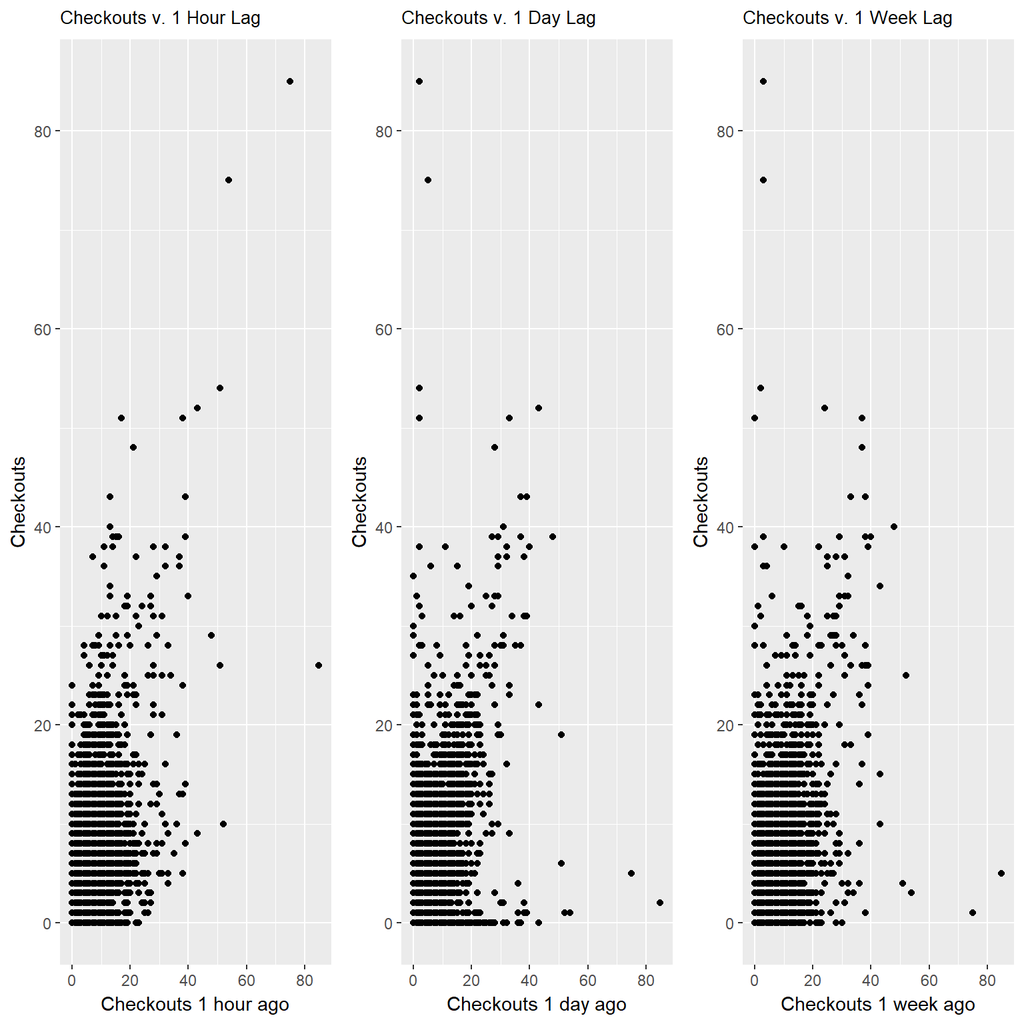

```r
gridExtra::grid.arrange(lag_1_hr,lag_1_day,lag_1_wk,
                        ncol = 3, nrow = 1)
```

Similarly, we found correlation between bike usage and weather related variables, as illustrated by the plots below.

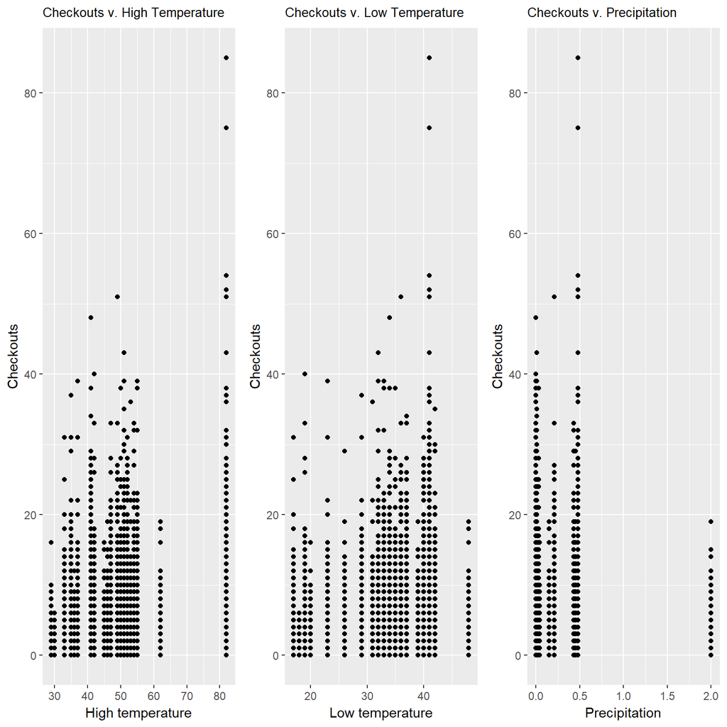

```r
gridExtra::grid.arrange(high_temp,low_temp,rain,
                        ncol = 3, nrow = 1)
```

# Model Building

We built three models for this exercise. We used the Ordinary Least Squared method to estimate the first model. For this model, we used both the backward and forward stepwise methods to select variables. As the plots show, both methods suggest that 19 variables (for factor variable, each level counts as a separate variable) could minimize prediction errors, indicated by Mallow’s Cp.

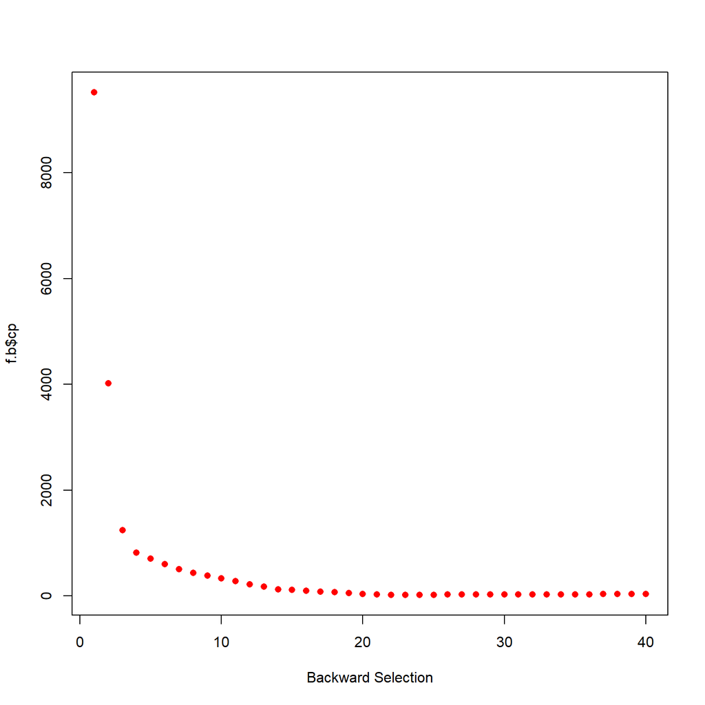

```r
fit.backward <- regsubsets(checkout ~ hour + lag.1hr + lag.2hr + lag.1day + lag.2day + lag.1wk +
                             weekend + dpcapacity + pop +
                             total.jobs + young.jobs + white.jobs + col.jobs + bach.jobs +
                             min.temp + max.temp + rain + dist.park + dist.loop + dist.lib +
                             pop.den + job.den + young.den + white.den + col.den + bach.den +
                             NEAR_DIST + busy.station,
                           data = train, nvmax=40, method="backward")

f.b <- summary(fit.backward)
plot(f.b$cp,  col="red", type="p", pch=16,
     xlab="Backward Selection")
```

```r
coef(fit.backward, 19)
```

```
##  (Intercept)        hour6        hour7        hour8       hour11
##  -1.60797753   0.23005231   0.47688946   0.51035675   0.21424868
##       hour12       hour13       hour14       hour15       hour16
##   0.27305546   0.22454345   0.23948102   0.42040991   0.78968677
##       hour17      lag.1hr     lag.1day     lag.2day      lag.1wk
##   0.77863432   0.27552302   0.29859945  -0.06014751   0.39604433
##   dpcapacity     min.temp     max.temp         rain busy.station
##   0.01142241   0.03750118  -0.01676437   0.96342698   0.45010259
```

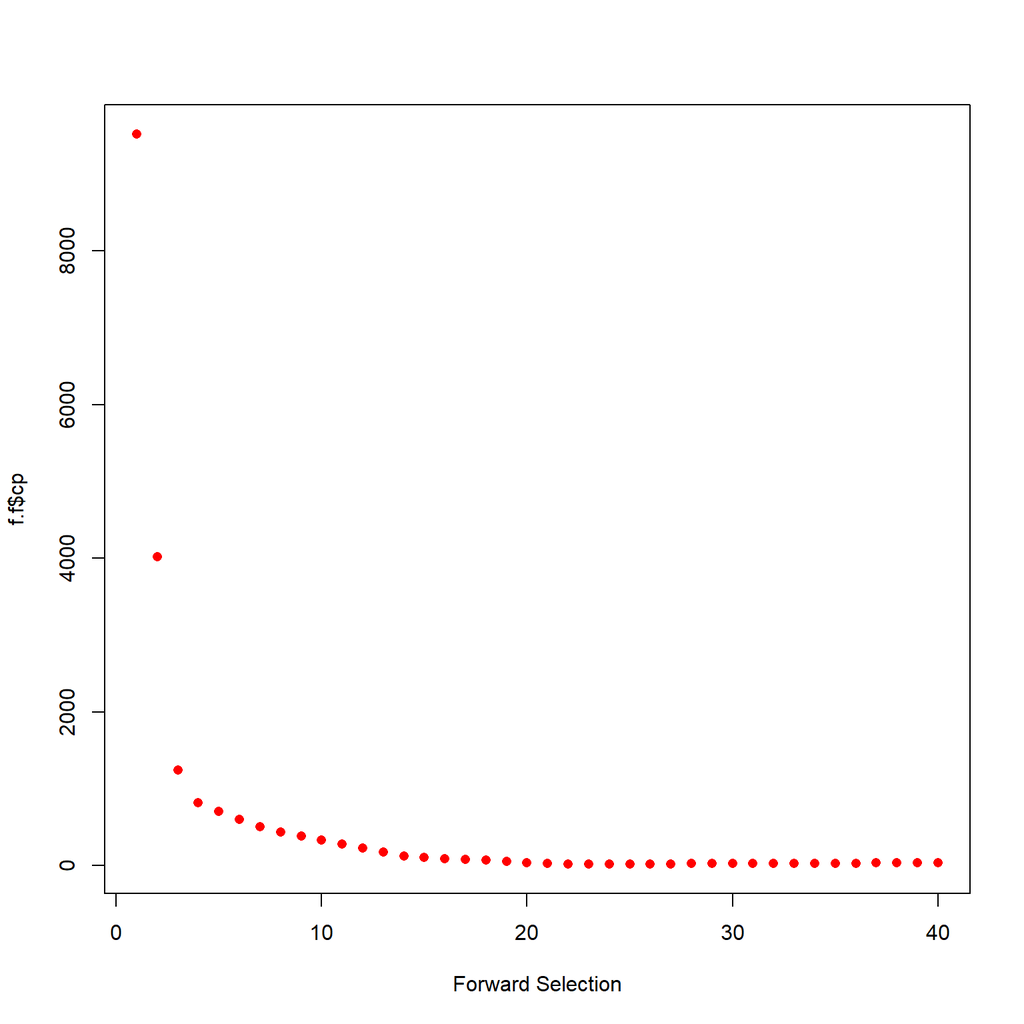

```r
fit.forward <- regsubsets(checkout ~ hour + lag.1hr + lag.2hr + lag.1day + lag.2day + lag.1wk +
                            weekend + dpcapacity + pop +
                            total.jobs + young.jobs + white.jobs + col.jobs + bach.jobs +
                            min.temp + max.temp + rain + dist.park + dist.loop + dist.lib +
                            pop.den + job.den + young.den + white.den + col.den + bach.den +
                            NEAR_DIST + busy.station,
                          data = train, nvmax=40, method="forward")

f.f <- summary(fit.forward)
plot(f.f$cp,  col="red", type="p", pch=16,
     xlab="Forward Selection")
```

```r
coef(fit.backward, 19)
```

```
##  (Intercept)        hour6        hour7        hour8       hour11
##  -1.60797753   0.23005231   0.47688946   0.51035675   0.21424868
##       hour12       hour13       hour14       hour15       hour16
##   0.27305546   0.22454345   0.23948102   0.42040991   0.78968677
##       hour17      lag.1hr     lag.1day     lag.2day      lag.1wk
##   0.77863432   0.27552302   0.29859945  -0.06014751   0.39604433
##   dpcapacity     min.temp     max.temp         rain busy.station
##   0.01142241   0.03750118  -0.01676437   0.96342698   0.45010259
```

```r
reg.lm.2 <- lm(checkout ~ hour + lag.1hr + lag.2hr + lag.1day + lag.2day + lag.1wk +
                 weekend + dpcapacity +
                 min.temp + max.temp + rain + busy.station,
               data = train)
summary(reg.lm.2)
```

```
##
## Call:
## lm(formula = checkout ~ hour + lag.1hr + lag.2hr + lag.1day +
##     lag.2day + lag.1wk + weekend + dpcapacity + min.temp + max.temp +
##     rain + busy.station, data = train)
##
## Residuals:
##      Min       1Q   Median       3Q      Max
## -13.0212  -0.6299  -0.1267   0.4062  26.6256
##
## Coefficients:
##               Estimate Std. Error t value Pr(>|t|)
## (Intercept)  -1.546312   0.094159 -16.422  < 2e-16 ***
## hour6         0.145918   0.064388   2.266 0.023448 *
## hour7         0.391173   0.064786   6.038 1.59e-09 ***
## hour8         0.424846   0.065369   6.499 8.27e-11 ***
## hour9        -0.136211   0.065250  -2.088 0.036855 *
## hour10       -0.023735   0.065166  -0.364 0.715697
## hour11        0.146670   0.064623   2.270 0.023242 *
## hour12        0.194155   0.064584   3.006 0.002648 **
## hour13        0.148583   0.064703   2.296 0.021665 *
## hour14        0.166568   0.064725   2.573 0.010076 *
## hour15        0.348280   0.064925   5.364 8.21e-08 ***
## hour16        0.713173   0.065911  10.820  < 2e-16 ***
## hour17        0.696992   0.067319  10.353  < 2e-16 ***
## hour18       -0.074800   0.066734  -1.121 0.262354
## hour19       -0.058157   0.066373  -0.876 0.380931
## hour20       -0.048659   0.064928  -0.749 0.453602
## hour21       -0.109294   0.064484  -1.695 0.090110 .
## hour22       -0.060587   0.064373  -0.941 0.346621
## hour23       -0.077091   0.064339  -1.198 0.230858
## lag.1hr       0.289168   0.006636  43.577  < 2e-16 ***
## lag.2hr      -0.022943   0.006111  -3.754 0.000174 ***
## lag.1day      0.298272   0.006856  43.506  < 2e-16 ***
## lag.2day     -0.058800   0.007218  -8.146 3.97e-16 ***
## lag.1wk       0.394650   0.006709  58.828  < 2e-16 ***
## weekend      -0.017828   0.028877  -0.617 0.536984
## dpcapacity    0.011877   0.001380   8.604  < 2e-16 ***
## min.temp      0.037597   0.002499  15.044  < 2e-16 ***
## max.temp     -0.016399   0.002727  -6.014 1.84e-09 ***
## rain          0.945852   0.100936   9.371  < 2e-16 ***
## busy.station  0.473193   0.058106   8.144 4.06e-16 ***
## ---
## Signif. codes:  0 '***' 0.001 '**' 0.01 '*' 0.05 '.' 0.1 ' ' 1
##
## Residual standard error: 1.469 on 19787 degrees of freedom
## Multiple R-squared:  0.5708, Adjusted R-squared:  0.5702
## F-statistic: 907.6 on 29 and 19787 DF,  p-value: < 2.2e-16
```

We then cross validated the model to get the related statistics. As the table below shows, the r-squared, root mean squared errors, and mean absolute errors are stable across samples, suggesting that the model’s performance is consistent. We applied this model to both testing sets to predict checkouts at each station.

```r
lmFit.2$resample
```

```
##        RMSE  Rsquared       MAE   Resample
## 1  1.419662 0.5978495 0.8904739 Resample01
## 2  1.468161 0.5535929 0.8868730 Resample02
## 3  1.450062 0.5427546 0.8757562 Resample03
## 4  1.536050 0.5924313 0.9041920 Resample04
## 5  1.516380 0.5744433 0.8878162 Resample05
## 6  1.511704 0.5830241 0.8867912 Resample06
## 7  1.425230 0.5617489 0.8789106 Resample07
## 8  1.427601 0.5434473 0.8748953 Resample08
## 9  1.442862 0.5443674 0.8922041 Resample09
## 10 1.446601 0.5669722 0.8838484 Resample10
## 11 1.410933 0.5952484 0.8810601 Resample11
## 12 1.560963 0.5715200 0.8956547 Resample12
## 13 1.554650 0.5718758 0.9121116 Resample13
## 14 1.468622 0.5686830 0.8815401 Resample14
## 15 1.522984 0.5681066 0.8931870 Resample15
## 16 1.504257 0.5320480 0.8762057 Resample16
## 17 1.482650 0.5675925 0.8965268 Resample17
## 18 1.499698 0.5275556 0.8929823 Resample18
## 19 1.416619 0.5602880 0.8749873 Resample19
## 20 1.436564 0.5626385 0.8728040 Resample20
## 21 1.444687 0.5836225 0.8840212 Resample21
## 22 1.508604 0.5655279 0.8887147 Resample22
## 23 1.498652 0.5662368 0.8927490 Resample23
## 24 1.424018 0.5550311 0.8793436 Resample24
## 25 1.483951 0.5369709 0.8852217 Resample25
```

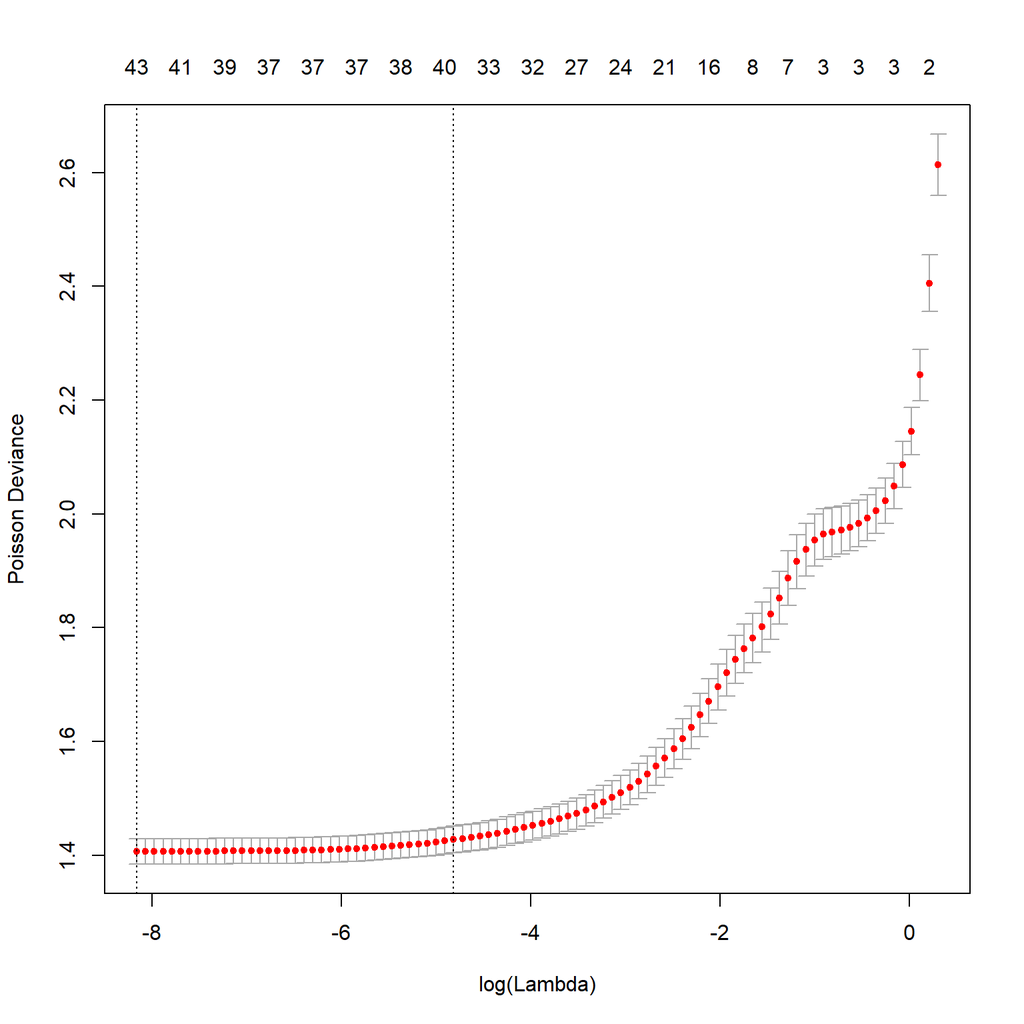

```r
plot(fit.cv.ps)
```

```r
coef.1se.ps <- coef(fit.cv.ps, s="lambda.1se")
nzcoef.ps  <- rownames(coef.1se.ps)[which((coef.1se.ps) != 0)]
nzcoef.ps
```

```
##  [1] "(Intercept)"  "hour6"        "hour7"        "hour8"
##  [5] "hour9"        "hour11"       "hour12"       "hour13"
##  [9] "hour14"       "hour15"       "hour16"       "hour17"
## [13] "hour18"       "hour19"       "hour20"       "hour21"
## [17] "hour22"       "hour23"       "lag.1hr"      "lag.2hr"
## [21] "lag.1day"     "lag.2day"     "lag.1wk"      "weekend"
## [25] "dpcapacity"   "pop"          "young.jobs"   "min.temp"
## [29] "max.temp"     "rain"         "dist.park"    "dist.loop"
## [33] "dist.lib"     "pop.den"      "col.den"      "busy.station"
```

```r
reg.lasso.1 <- glm(checkout ~ hour + lag.1hr + lag.2hr + lag.1day + lag.2day + lag.1wk +
                   weekend + dpcapacity + pop +
                   total.jobs + young.jobs + bach.jobs +
                   min.temp + max.temp + rain + dist.park + dist.loop + dist.lib +
                   pop.den + col.den + busy.station,
                 family = "poisson",
                 data = train)
summary(reg.lasso.1)
```

```
##
## Call:
## glm(formula = checkout ~ hour + lag.1hr + lag.2hr + lag.1day +
##     lag.2day + lag.1wk + weekend + dpcapacity + pop + total.jobs +
##     young.jobs + bach.jobs + min.temp + max.temp + rain + dist.park +
##     dist.loop + dist.lib + pop.den + col.den + busy.station,
##     family = "poisson", data = train)
##
## Deviance Residuals:
##      Min        1Q    Median        3Q       Max
## -11.5851   -1.0788   -0.5882    0.3809    9.0528
##
## Coefficients:
##                Estimate Std. Error z value Pr(>|z|)
## (Intercept)  -3.361e+00  1.008e-01 -33.335  < 2e-16 ***
## hour6         1.185e+00  8.166e-02  14.515  < 2e-16 ***
## hour7         1.739e+00  7.701e-02  22.587  < 2e-16 ***
## hour8         1.825e+00  7.653e-02  23.844  < 2e-16 ***
## hour9         1.396e+00  7.918e-02  17.626  < 2e-16 ***
## hour10        1.084e+00  8.228e-02  13.177  < 2e-16 ***
## hour11        1.426e+00  7.950e-02  17.937  < 2e-16 ***
## hour12        1.586e+00  7.838e-02  20.233  < 2e-16 ***
## hour13        1.597e+00  7.823e-02  20.415  < 2e-16 ***
## hour14        1.587e+00  7.828e-02  20.278  < 2e-16 ***
## hour15        1.850e+00  7.677e-02  24.097  < 2e-16 ***
## hour16        2.268e+00  7.493e-02  30.272  < 2e-16 ***
## hour17        2.338e+00  7.454e-02  31.368  < 2e-16 ***
## hour18        1.815e+00  7.651e-02  23.717  < 2e-16 ***
## hour19        1.319e+00  8.009e-02  16.464  < 2e-16 ***
## hour20        8.831e-01  8.452e-02  10.448  < 2e-16 ***
## hour21        3.034e-01  9.400e-02   3.228  0.00125 **
## hour22       -1.469e-02  1.017e-01  -0.144  0.88513
## hour23       -4.892e-01  1.166e-01  -4.198 2.70e-05 ***
## lag.1hr       3.122e-02  2.140e-03  14.586  < 2e-16 ***
## lag.2hr       1.842e-02  2.465e-03   7.475 7.74e-14 ***
## lag.1day      3.582e-02  2.050e-03  17.472  < 2e-16 ***
## lag.2day     -1.891e-02  2.616e-03  -7.226 4.96e-13 ***
## lag.1wk       5.160e-02  1.914e-03  26.956  < 2e-16 ***
## weekend      -3.242e-01  2.081e-02 -15.581  < 2e-16 ***
## dpcapacity    2.054e-02  9.785e-04  20.987  < 2e-16 ***
```

[output cut: 8 more lines]

```
## dist.loop    -7.266e-05  3.035e-06 -23.942  < 2e-16 ***
## dist.lib      5.771e-05  5.927e-06   9.738  < 2e-16 ***
## pop.den       4.074e-04  1.524e-04   2.673  0.00753 **
## col.den      -3.952e-04  6.202e-05  -6.372 1.86e-10 ***
## busy.station  2.749e-01  2.613e-02  10.521  < 2e-16 ***
## ---
## Signif. codes:  0 '***' 0.001 '**' 0.01 '*' 0.05 '.' 0.1 ' ' 1
##
## (Dispersion parameter for poisson family taken to be 1)
##
##     Null deviance: 51934  on 19816  degrees of freedom
## Residual deviance: 27543  on 19778  degrees of freedom
## AIC: 49076
##
## Number of Fisher Scoring iterations: 6
```

Lastly, we built a negative binomial model. For this model, we resorted to the backward stepwise selection method. We first included all variables. Then, one by one, we eliminated variables that were not statistically significant. This process left us with the following model.

```r
reg.nb.2 <- glm.nb(checkout ~ hour + lag.1hr + lag.2hr + lag.1day + lag.2day + lag.1wk +
                     weekend + dpcapacity + pop +
                     total.jobs + young.jobs + white.jobs + col.jobs + bach.jobs +
                     min.temp + max.temp + rain + dist.park + dist.loop + dist.lib +
                     job.den + young.den + white.den + col.den + bach.den +
                     NEAR_DIST,
                   data = train)
summary(reg.nb.2)
```

```
##
## Call:
## glm.nb(formula = checkout ~ hour + lag.1hr + lag.2hr + lag.1day +
##     lag.2day + lag.1wk + weekend + dpcapacity + pop + total.jobs +
##     young.jobs + white.jobs + col.jobs + bach.jobs + min.temp +
##     max.temp + rain + dist.park + dist.loop + dist.lib + job.den +
##     young.den + white.den + col.den + bach.den + NEAR_DIST, data = train,
##     init.theta = 2.062111856, link = log)
##
## Deviance Residuals:
##     Min       1Q   Median       3Q      Max
## -4.7506  -0.9594  -0.5545   0.3208   5.4074
##
## Coefficients:
##               Estimate Std. Error z value Pr(>|z|)
## (Intercept) -3.327e+00  1.231e-01 -27.027  < 2e-16 ***
## hour6        9.727e-01  9.055e-02  10.742  < 2e-16 ***
## hour7        1.426e+00  8.638e-02  16.503  < 2e-16 ***
## hour8        1.698e+00  8.469e-02  20.048  < 2e-16 ***
## hour9        1.243e+00  8.752e-02  14.200  < 2e-16 ***
## hour10       1.032e+00  8.971e-02  11.506  < 2e-16 ***
## hour11       1.328e+00  8.705e-02  15.256  < 2e-16 ***
## hour12       1.457e+00  8.609e-02  16.925  < 2e-16 ***
## hour13       1.466e+00  8.595e-02  17.055  < 2e-16 ***
## hour14       1.434e+00  8.617e-02  16.636  < 2e-16 ***
## hour15       1.643e+00  8.491e-02  19.351  < 2e-16 ***
## hour16       1.893e+00  8.379e-02  22.587  < 2e-16 ***
## hour17       1.816e+00  8.435e-02  21.532  < 2e-16 ***
## hour18       1.485e+00  8.594e-02  17.282  < 2e-16 ***
## hour19       1.163e+00  8.866e-02  13.115  < 2e-16 ***
## hour20       8.134e-01  9.194e-02   8.847  < 2e-16 ***
## hour21       2.867e-01  1.004e-01   2.856 0.004295 **
## hour22      -9.447e-03  1.076e-01  -0.088 0.930044
## hour23      -4.707e-01  1.218e-01  -3.865 0.000111 ***
## lag.1hr      6.439e-02  4.286e-03  15.022  < 2e-16 ***
## lag.2hr      2.283e-02  4.185e-03   5.454 4.92e-08 ***
## lag.1day     7.018e-02  4.255e-03  16.492  < 2e-16 ***
## lag.2day    -8.341e-03  4.939e-03  -1.689 0.091234 .
## lag.1wk      1.152e-01  4.158e-03  27.707  < 2e-16 ***
## weekend     -2.162e-01  2.733e-02  -7.911 2.55e-15 ***
```

[output cut: 20 more lines]

```
## Signif. codes:  0 '***' 0.001 '**' 0.01 '*' 0.05 '.' 0.1 ' ' 1
##
## (Dispersion parameter for Negative Binomial(2.0621) family taken to be 1)
##
##     Null deviance: 32476  on 19816  degrees of freedom
## Residual deviance: 17562  on 19773  degrees of freedom
## AIC: 45237
##
## Number of Fisher Scoring iterations: 1
##
##
##               Theta:  2.0621
##           Std. Err.:  0.0697
##
##  2 x log-likelihood:  -45146.6140
```

We then predicted the outcomes using this negative binomial model.

# Model Comparison and Discussion

A brief examination of the outcomes from each model reveals the following findings. One, the OLS moddel yielded negative predictions, which are expected but not realistic in the current case. Two, the negative binomial model yielded highly unrealistic outlying nubers. We therefore decided to discard the negative binomial model, and consider all negative predictions from the OLS model as zero checkout.

```r
summary(test.wk$lmfit)
```

```
##    Min. 1st Qu.  Median    Mean 3rd Qu.    Max.
## -0.7765 -0.2993  0.1953  0.7695  1.0535 30.0737
```

```r
summary(test.wk$psfit)
```

```
##     Min.  1st Qu.   Median     Mean  3rd Qu.     Max.
##  0.03291  0.24296  0.46094  0.70014  0.78501 45.61485
```

```r
summary(test.wk$nbfit)
```

```
##      Min.   1st Qu.    Median      Mean   3rd Qu.      Max.
##    0.0251    0.2148    0.4194    2.3104    0.7330 2903.9574
```

The plots below show the comparison of distribution between the observed hourly checkouts on weekdays and weekends and predicted ones using OLS. The model predicts the aggregate checkouts fairly well for weekdays. However, there are some visible discrepency between the observed and predicted values on weekends.

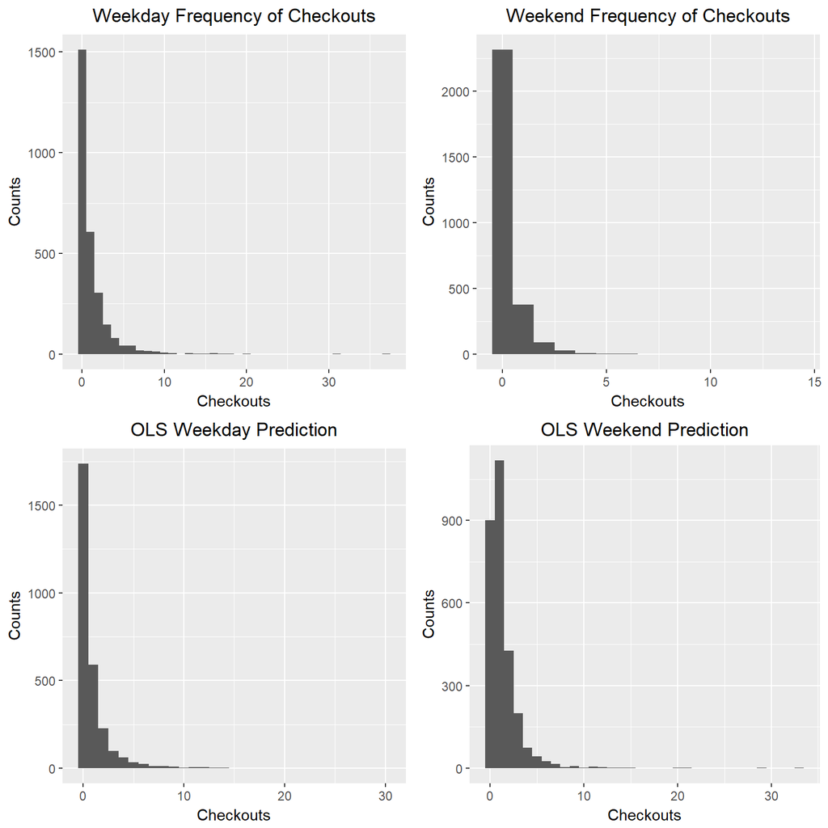

```r
gridExtra::grid.arrange(ob.wk,ob.wknd,lm.wk,lm.wknd,
                        ncol = 2, nrow = 2)
```

The Poisson model does not seem to estimate the number of checkouts well. As shown in the plots below, there are significant differences between the observed and predicted values for both weekdays and weekends, although predictions for weekends seem more accurate than those for weekdays.

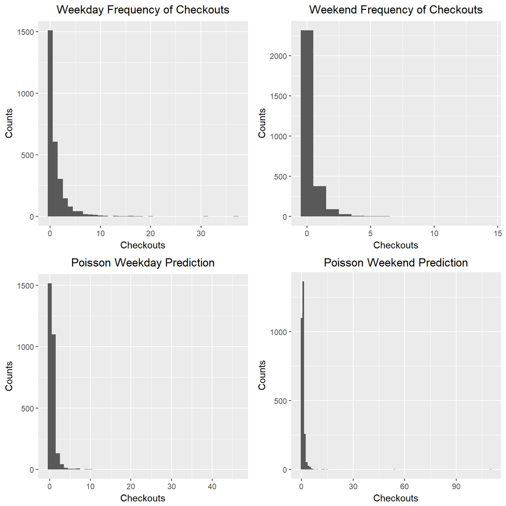

```r
gridExtra::grid.arrange(ob.wk,ob.wknd,ps.wk,ps.wknd,
                        ncol = 2, nrow = 2)
```

The plots below show the relationship between predicted and observed values for each model on weekdays and weekends. Ideally, the dots should cluster along the blue line, meaning there is little difference between the predicted and observed values. This is clearly not the case for weekend checkouts using OLS as the prediction model.

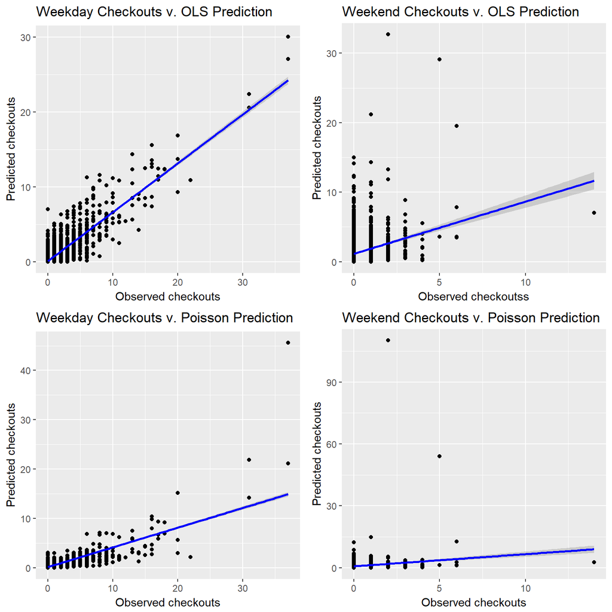

```r
gridExtra::grid.arrange(scatter.wk.lm,scatter.wknd.lm,scatter.wk.ps,scatter.wknd.ps,
                        ncol = 2, nrow = 2)
```

We came to similar conclusion by using relevant statistics. The table below shows the mean absolute error for each model. We included the negative binomial model here for the purpose of comparison. Overall, the OLS model predicts weekday checkouts better than the other two models, whereas the Poisson model predicts weekends better. On average, the OLS mispredicts roughly 0.75 checkouts at a given our for a single station, whereas the Poisson model mispredicts 0.84 checkouts on the weekends. Both predictions are acceptable given that they are within a one-checkout margin of error.

```r
accuracy.tab
```

```
##     model    method       MAE
## 1 weekday       OLS 0.7599744
## 2 weekday   Poisson 0.9874064
## 3 weekday Neg.Binom 2.3657434
## 4 weekend       OLS 1.1998691
## 5 weekend   Poisson 0.8378554
## 6 weekend Neg.Binom 2.9784046
```

The plots below confirm our conclusion. Both models perform well in predicting the general pattern of checkouts on weekdays, with the OLS model having a higher accuracy than the Poisson model. However, both models under-predict to a certain degree. The weekends see a different story. Both models over-predict checkouts by a significant amount, with the Poisson model doing a slightly better job.

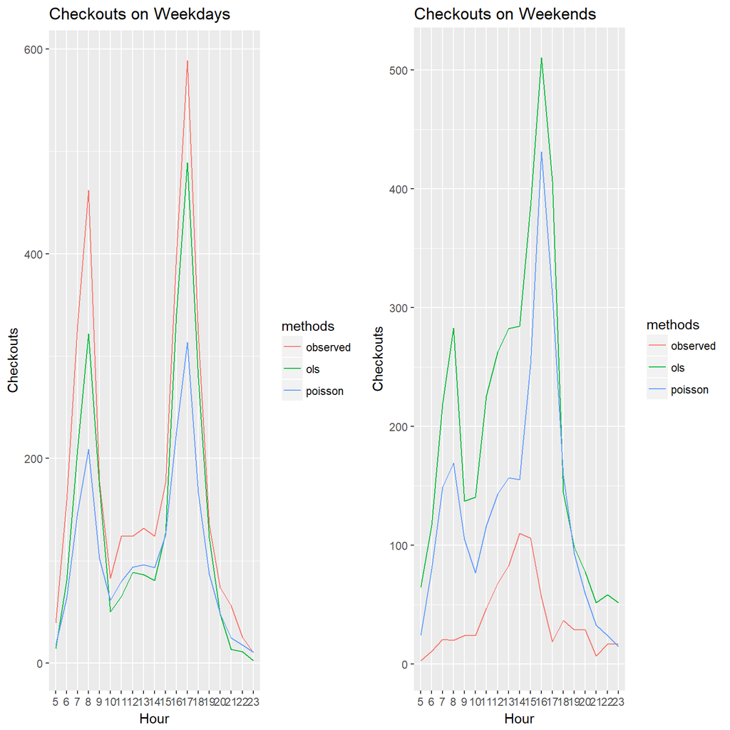

```r
gridExtra::grid.arrange(hourly.agg.week,hourly.agg.weekend,
                        ncol = 2, nrow = 1)
```

To see how generalizable our models are, we selected three stations with different levels of usage. The OLS model predicts the high and medium usage stations more effectively than the Poisson model for weekdays. Neither model does a good job predicting the low usage station and station usage on the weekend.

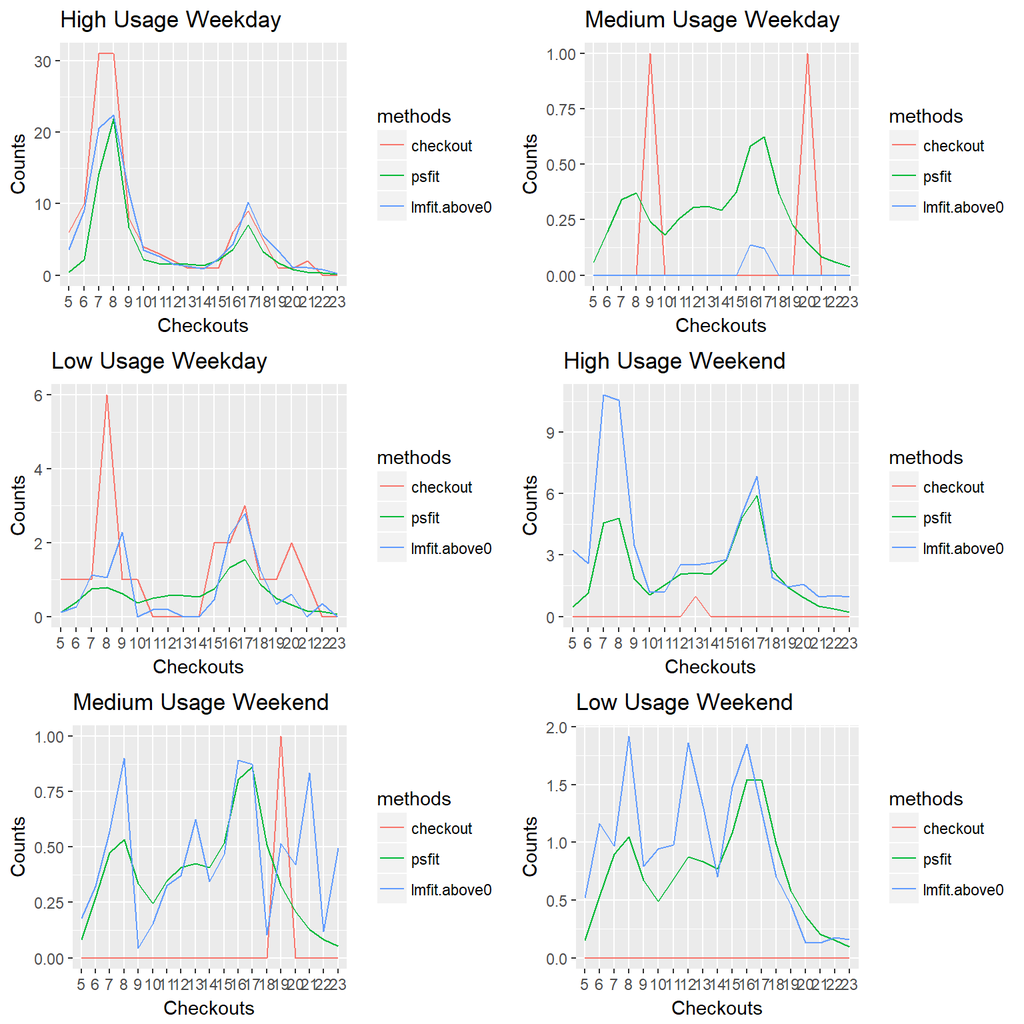

```r
gridExtra::grid.arrange(week.192.plot, week.135.plot, week.233.plot,
                        weeknd.192.plot, weeknd.135.plot, weeknd.233.plot,
                        ncol = 2, nrow = 3)
```

# Conclusion and Discussion

While this analysis suggested several methods for predicting bike share usage, it illustrates just how difficult it is to come up with accurate predictions on the micro level. There are a few things that we could do to potentially improve the analysis. First, instead of examining all bike stations, we focus on those that in the past had experienced balancing issues. It could take the form of a two staged analysis where on the first stage, we predict the possibility of a station running out of bikes at any given hour using binomial regression. On the second stage, we predict the actual bike chekouts using either negative binomial or Poisson regression. Second, we were not able to find a way to cross validate the negative binomial and Poisson models. It might have helped us with our variable selection if we had found a proper way for cross validation. Lastly, there must certainly have been factors that eluded us when we collected our data. Some of these factors might have helped us improve the performance of our models.